# Atualização de pacotes, default de programas, funções básicas

### **4.3 Data Frame**

Data frame é o tipo de objeto que geralmente mais utilizamos. Ele é usado para armazenar tabelas de dados. É uma lista de vetores de mesmo tamanho. Vamos olhar o exemplo para entender melhor. Vamos criar um data frame ‘df’ com três vetores.

```r
a <- c(2, 3, 5)
b <- c("aa", "bb", "cc")
c <- c(TRUE, FALSE, TRUE)
df = data.frame(a, b, c)
```

Podemos acessar os elementos do data frame da mesma forma que na matrix. Vamos usar uma base de dados que já está presente no R (iris)

```r
iris
```

```
##     Sepal.Length Sepal.Width Petal.Length Petal.Width    Species
## 1            5.1         3.5          1.4         0.2     setosa
## 2            4.9         3.0          1.4         0.2     setosa
## 3            4.7         3.2          1.3         0.2     setosa
## 4            4.6         3.1          1.5         0.2     setosa
## 5            5.0         3.6          1.4         0.2     setosa
## 6            5.4         3.9          1.7         0.4     setosa
## 7            4.6         3.4          1.4         0.3     setosa
## 8            5.0         3.4          1.5         0.2     setosa
## 9            4.4         2.9          1.4         0.2     setosa
## 10           4.9         3.1          1.5         0.1     setosa
## 11           5.4         3.7          1.5         0.2     setosa
## 12           4.8         3.4          1.6         0.2     setosa
## 13           4.8         3.0          1.4         0.1     setosa
## 14           4.3         3.0          1.1         0.1     setosa
```

[output cut: 136 more lines]

A primeira linha contém os nomes das colunas (variáveis) e é chamada pela programa de ‘header’. Na horizontal estão as linhas de dados, que pode ou não começar com o nome das linhas. Por exemplo, em análises filogenéticas cada linha corresponderia a uma espécie. Cada dado de uma linha é chamada de célula. Para acessar o dado de uma célula, é possível usar as coordenadas de linha e coluna separadas por vírgulas entre colchetes ‘[]’. A exemplo da matriz, a ordem de linha e coluna é importante.

```r
iris[1, 2]
```

```
## [1] 3.5
```

Adicionalmente, podemos usar os nomes das linhas e colunas em vez das coordenadas numéricas. Vamos usar o conjunto de dados mtcars como exemplo.

```r
mtcars
```

```
##                      mpg cyl  disp  hp drat    wt  qsec vs am gear carb
## Mazda RX4           21.0   6 160.0 110 3.90 2.620 16.46  0  1    4    4
## Mazda RX4 Wag       21.0   6 160.0 110 3.90 2.875 17.02  0  1    4    4
## Datsun 710          22.8   4 108.0  93 3.85 2.320 18.61  1  1    4    1
## Hornet 4 Drive      21.4   6 258.0 110 3.08 3.215 19.44  1  0    3    1
## Hornet Sportabout   18.7   8 360.0 175 3.15 3.440 17.02  0  0    3    2
## Valiant             18.1   6 225.0 105 2.76 3.460 20.22  1  0    3    1
## Duster 360          14.3   8 360.0 245 3.21 3.570 15.84  0  0    3    4
## Merc 240D           24.4   4 146.7  62 3.69 3.190 20.00  1  0    4    2
## Merc 230            22.8   4 140.8  95 3.92 3.150 22.90  1  0    4    2
## Merc 280            19.2   6 167.6 123 3.92 3.440 18.30  1  0    4    4
## Merc 280C           17.8   6 167.6 123 3.92 3.440 18.90  1  0    4    4
## Merc 450SE          16.4   8 275.8 180 3.07 4.070 17.40  0  0    3    3
## Merc 450SL          17.3   8 275.8 180 3.07 3.730 17.60  0  0    3    3
## Merc 450SLC         15.2   8 275.8 180 3.07 3.780 18.00  0  0    3    3
## Cadillac Fleetwood  10.4   8 472.0 205 2.93 5.250 17.98  0  0    3    4
## Lincoln Continental 10.4   8 460.0 215 3.00 5.424 17.82  0  0    3    4
## Chrysler Imperial   14.7   8 440.0 230 3.23 5.345 17.42  0  0    3    4
## Fiat 128            32.4   4  78.7  66 4.08 2.200 19.47  1  1    4    1
## Honda Civic         30.4   4  75.7  52 4.93 1.615 18.52  1  1    4    2
## Toyota Corolla      33.9   4  71.1  65 4.22 1.835 19.90  1  1    4    1
## Toyota Corona       21.5   4 120.1  97 3.70 2.465 20.01  1  0    3    1
## Dodge Challenger    15.5   8 318.0 150 2.76 3.520 16.87  0  0    3    2
## AMC Javelin         15.2   8 304.0 150 3.15 3.435 17.30  0  0    3    2
## Camaro Z28          13.3   8 350.0 245 3.73 3.840 15.41  0  0    3    4
## Pontiac Firebird    19.2   8 400.0 175 3.08 3.845 17.05  0  0    3    2
## Fiat X1-9           27.3   4  79.0  66 4.08 1.935 18.90  1  1    4    1
## Porsche 914-2       26.0   4 120.3  91 4.43 2.140 16.70  0  1    5    2
## Lotus Europa        30.4   4  95.1 113 3.77 1.513 16.90  1  1    5    2
## Ford Pantera L      15.8   8 351.0 264 4.22 3.170 14.50  0  1    5    4
## Ferrari Dino        19.7   6 145.0 175 3.62 2.770 15.50  0  1    5    6
## Maserati Bora       15.0   8 301.0 335 3.54 3.570 14.60  0  1    5    8
## Volvo 142E          21.4   4 121.0 109 4.11 2.780 18.60  1  1    4    2
```

```r
head(mtcars)
```

```
##                    mpg cyl disp  hp drat    wt  qsec vs am gear carb
## Mazda RX4         21.0   6  160 110 3.90 2.620 16.46  0  1    4    4
## Mazda RX4 Wag     21.0   6  160 110 3.90 2.875 17.02  0  1    4    4
## Datsun 710        22.8   4  108  93 3.85 2.320 18.61  1  1    4    1
## Hornet 4 Drive    21.4   6  258 110 3.08 3.215 19.44  1  0    3    1
## Hornet Sportabout 18.7   8  360 175 3.15 3.440 17.02  0  0    3    2
## Valiant           18.1   6  225 105 2.76 3.460 20.22  1  0    3    1
```

```r
mtcars["Mazda RX4", "cyl"]
```

```
## [1] 6
```

Há outra maneira também de acessar apenas uma determinada coluna

```r
iris$Sepal.Width
```

```
##   [1] 3.5 3.0 3.2 3.1 3.6 3.9 3.4 3.4 2.9 3.1 3.7 3.4 3.0 3.0 4.0 4.4 3.9
##  [18] 3.5 3.8 3.8 3.4 3.7 3.6 3.3 3.4 3.0 3.4 3.5 3.4 3.2 3.1 3.4 4.1 4.2
##  [35] 3.1 3.2 3.5 3.6 3.0 3.4 3.5 2.3 3.2 3.5 3.8 3.0 3.8 3.2 3.7 3.3 3.2
##  [52] 3.2 3.1 2.3 2.8 2.8 3.3 2.4 2.9 2.7 2.0 3.0 2.2 2.9 2.9 3.1 3.0 2.7
##  [69] 2.2 2.5 3.2 2.8 2.5 2.8 2.9 3.0 2.8 3.0 2.9 2.6 2.4 2.4 2.7 2.7 3.0
##  [86] 3.4 3.1 2.3 3.0 2.5 2.6 3.0 2.6 2.3 2.7 3.0 2.9 2.9 2.5 2.8 3.3 2.7
## [103] 3.0 2.9 3.0 3.0 2.5 2.9 2.5 3.6 3.2 2.7 3.0 2.5 2.8 3.2 3.0 3.8 2.6
## [120] 2.2 3.2 2.8 2.8 2.7 3.3 3.2 2.8 3.0 2.8 3.0 2.8 3.8 2.8 2.8 2.6 3.0
## [137] 3.4 3.1 3.0 3.1 3.1 3.1 2.7 3.2 3.3 3.0 2.5 3.0 3.4 3.0
```

E se for conveniente, separá-la em um vetor.

```r
SW <- iris$Sepal.Width
```

### **4.4 Listas**

É o tipo mais geral de estrutura de dados. Consiste em uma coleção ordenada de outros objetos (componentes). Não é necessário que o componente seja do mesmo tipo, podendo por exemplo consitir de uma matrix, um vetor, uma função e também uma árvore filogenética. Vamos ver a estrutura de uma árvore:

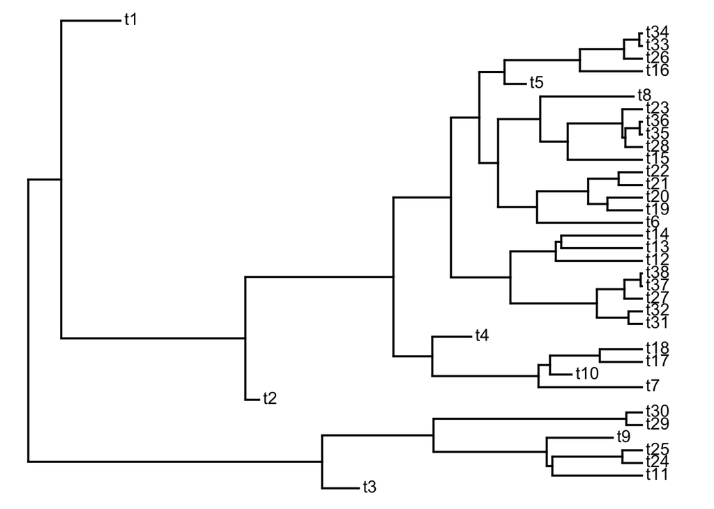

```r
require(phytools)
set.seed(1)
tree<-pbtree(b=1,d=0.2,n=30)
plotTree(tree)
```

```r
str(tree)
```

```
## List of 4
##  $ edge       : int [1:74, 1:2] 39 40 40 41 42 43 43 44 44 42 ...
##  $ Nnode      : int 37
##  $ tip.label  : chr [1:38] "t3" "t11" "t24" "t25" ...
##  $ edge.length: num [1:74] 2.8112 0.3507 1.0663 1.0831 0.0534 ...
##  - attr(*, "class")= chr "phylo"
##  - attr(*, "order")= chr "cladewise"
```

Para acessar cada objeto da lista, podemos usar o operador $. Por exemplo tree$tip.label para os nomes dos taxons.

## **5.Carregando dados de arquivos no R**

Há diversas funções para carregar arquivos no R. Para conjuntos de dados, normalmente usamos read.table() e read.csv(). Cada uma geralmente é usada para um tipo de dados (por exemplo csv), mas read.table() é mais geral e poderia ser customizada para ler um csv (mas para que tanto trabalho?). Lembre-se que você pode buscar informações sobre elas usando help(). Vamos tentar ler alguns dados.

```r
phylo.data <- read.table('http://cl.ly/3O2j1H3j2c3K/data.csv',
                         sep=',', header=TRUE, row.names=1)
head(phylo.data)
```

```
##          svl     head limblength
## t3  45.92212 5.314029   10.72143
## t11 45.49512 3.597874   16.85841
## t24 46.30994 4.403279   16.82461
## t25 46.85457 4.694902   17.04668
## t9  45.19916 4.174669   18.19975
## t29 46.98790 4.634824   12.92338
```

Com read.csv(), o default já considera o nome das colunas

```r
phylo.data <- read.csv('http://cl.ly/3O2j1H3j2c3K/data.csv',
                         row.names=1)
head(phylo.data)
```

```
##          svl     head limblength
## t3  45.92212 5.314029   10.72143
## t11 45.49512 3.597874   16.85841
## t24 46.30994 4.403279   16.82461
## t25 46.85457 4.694902   17.04668
## t9  45.19916 4.174669   18.19975
## t29 46.98790 4.634824   12.92338
```

Para abrir uma árvore, podemos usar read.nexus() ou read.tree(). Vamos tentar com a árvore que simulei anteriormente.

```r
tree<-read.tree('http://cl.ly/0Q2d2z2r0b2L/tree.tre')
```

Você pode checar usando a função plotTree() do pacote phytools.